# Continuous exposures and g-computation

## The Parametric G-Formula

1. Fit a model for `y ~ x + z` where `z` is all confounders (maybe even `y ~ x*z` to allow for heterogeneous treatment effects)
2. Create a duplicate of your dataset for each level of `x`
3. Set `x` to a single value in each cloned dataset
4. Make predictions using the model on each cloned dataset
5. Calculate the estimate you want, e.g. `mean(x_1) - mean(x_0)`

## Advantages of the parametric G-formula

**Often more statistically precise than propensity-based methods**

**Incredibly flexible** works for binary, continuous, and time-varying exposures

### Does having Extra Magic Morning hours influence the average **posted** wait time for Seven Dwarfs Mine Train between 9 and 10am?

## The Data

| park_date | park_extra_magic_morning | park_ticket_season | park_close | park_temperature_high | wait_minutes_posted_avg |
| --- | --- | --- | --- | --- | --- |
| 2018-01-01 | 0 | peak | 23:00:00 | 58.63 | 60.00000 |
| 2018-01-02 | 0 | peak | 24:00:00 | 53.65 | 60.00000 |
| 2018-01-03 | 0 | peak | 24:00:00 | 51.11 | 60.00000 |
| 2018-01-04 | 0 | regular | 24:00:00 | 52.66 | 68.88889 |
| 2018-01-05 | 1 | regular | 24:00:00 | 54.29 | 70.55556 |
| 2018-01-06 | 0 | regular | 23:00:00 | 56.25 | 33.33333 |
| 2018-01-07 | 0 | regular | 21:00:00 | 65.21 | 46.36364 |
| 2018-01-08 | 0 | value | 20:00:00 | 70.77 | 69.54545 |
| 2018-01-09 | 0 | value | 20:00:00 | 75.15 | 64.28571 |
| 2018-01-10 | 0 | value | 20:00:00 | 74.25 | 74.28571 |

## 1. Fit the outcome model

```r
gcomp_model <- lm(
  wait_minutes_posted_avg ~
    park_extra_magic_morning +
    park_ticket_season +
    park_close +
    park_temperature_high,
  data = seven_dwarfs_9
)
```

The model must include all variables in the **adjustment set** from the causal diagram.

## 2 & 3. Clone and set exposure

```r
# set all park dates to have Extra Magic Morning
exposed <- seven_dwarfs_9 |>
  mutate(park_extra_magic_morning = 1)

# set all park dates to have no Extra Magic Morning
unexposed <- seven_dwarfs_9 |>
  mutate(park_extra_magic_morning = 0)
```

Each park date is “cloned” twice — once into a world where Extra Magic Morning **occurred**, and once where it **did not**. Covariates stay the same; only the exposure changes.

## 4. Make predictions

```r
pred_exposed <- gcomp_model |>
  augment(newdata = exposed) |>
  select(pred_exposed = .fitted)

pred_unexposed <- gcomp_model |>
  augment(newdata = unexposed) |>
  select(pred_unexposed = .fitted)
```

## 5. Calculate the estimate

```r
bind_cols(pred_exposed, pred_unexposed) |>
  summarize(
    mean_exposed   = mean(pred_exposed),
    mean_unexposed = mean(pred_unexposed),
    difference     = mean_exposed - mean_unexposed
  )
```

```
# A tibble: 1 × 3
  mean_exposed mean_unexposed difference
         <dbl>          <dbl>      <dbl>
1         74.2           68.1       6.16
```

## Or use `{marginaleffects}`

```r
library(marginaleffects)
avg_comparisons(
  gcomp_model,
  variables = "park_extra_magic_morning"
)
```

```
 Estimate Std. Error    z Pr(>|z|)   S 2.5 % 97.5 %
     6.16       2.26 2.73  0.00636 7.3  1.74   10.6

Term: park_extra_magic_morning
Type:  response
Comparison: 1 - 0
```

### Continuous exposures

### **We recommend g-computation over propensity scores for continuous exposures because of stability issues**

## Continuous exposure

Do *posted* wait times at 8am affect *actual* wait times at 9am?

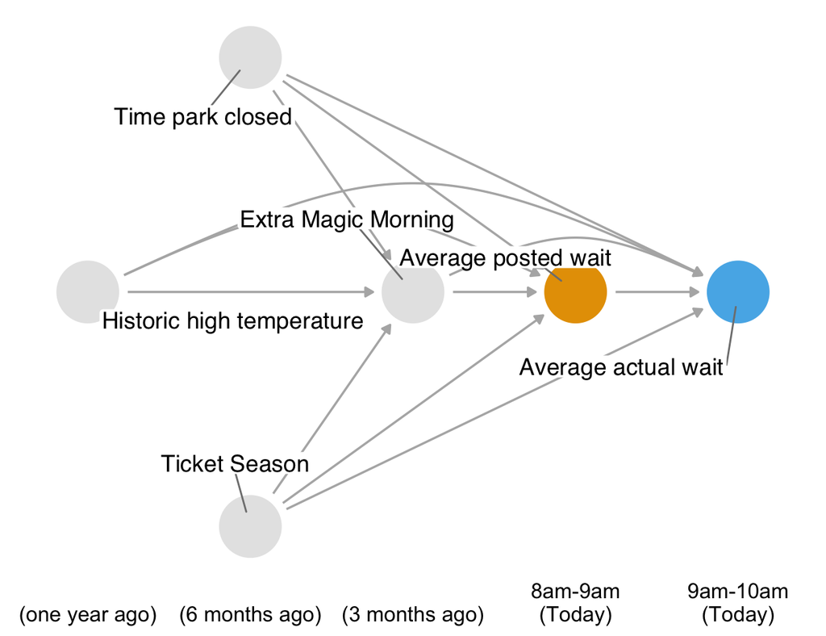

## Set up the data

```r
eight <- seven_dwarfs_train_2018 |>
  filter(wait_hour == 8) |>
  select(-wait_minutes_actual_avg)

nine <- seven_dwarfs_train_2018 |>
  filter(wait_hour == 9) |>
  select(park_date, wait_minutes_actual_avg)

wait_times <- eight |>
  left_join(nine, by = "park_date") |>
  drop_na(wait_minutes_actual_avg)
```

## 1. Fit the outcome model

```r
fit_wait <- lm(
  wait_minutes_actual_avg ~
    splines::ns(wait_minutes_posted_avg, df = 3) +
    park_extra_magic_morning +
    park_ticket_season +
    park_close +
    park_temperature_high,
  data = wait_times
)
```

We use a natural spline to flexibly model the potentially nonlinear relationship between posted and actual wait times.

## 2 & 3. Clone and set exposure

```r
# what if posted wait was 30 minutes for everyone?
low  <- wait_times |> mutate(wait_minutes_posted_avg = 30)

# what if posted wait was 60 minutes for everyone?
high <- wait_times |> mutate(wait_minutes_posted_avg = 60)
```

For a continuous exposure, we choose **specific values** to compare — here, 30 vs 60 minutes posted wait.

## 4 & 5. Predict and estimate

```r
pred_high <- fit_wait |> augment(newdata = high) |> select(pred_high = .fitted)
pred_low  <- fit_wait |> augment(newdata = low)  |> select(pred_low  = .fitted)

bind_cols(pred_high, pred_low) |>
  summarize(
    mean_high  = mean(pred_high),
    mean_low   = mean(pred_low),
    difference = mean_high - mean_low
  )
```

```
# A tibble: 1 × 3
  mean_high mean_low difference
      <dbl>    <dbl>      <dbl>
1      29.8     40.7      -10.8
```

## Or use `{marginaleffects}`

```r
avg_comparisons(
  fit_wait,
  variables = list(wait_minutes_posted_avg = c(30, 60))
)
```

```
 Estimate Std. Error     z Pr(>|z|)   S 2.5 % 97.5 %
    -10.8       8.13 -1.33    0.182 2.5 -26.8   5.09

Term: wait_minutes_posted_avg
Type:  response
Comparison: 60 - 30
```

### **Uncertainty quantification**

## Write a bootstrap function

```r
fit_gcomp <- function(.split, ...) {
  .df <- as.data.frame(.split)

  # fit outcome model
  fit <- lm(
    wait_minutes_actual_avg ~
      splines::ns(wait_minutes_posted_avg, df = 3) +
      park_extra_magic_morning + park_ticket_season +
      park_close + park_temperature_high,
    data = .df
  )

  # clone and set exposure
  low  <- .df |> mutate(wait_minutes_posted_avg = 30)
  high <- .df |> mutate(wait_minutes_posted_avg = 60)

  # predict
  pred_low  <- fit |> augment(newdata = low)  |> pull(.fitted)
  pred_high <- fit |> augment(newdata = high) |> pull(.fitted)

  # estimate
  tibble(
    term     = "difference",
    estimate = mean(pred_high) - mean(pred_low)
  )
}
```

## Bootstrap with `{rsample}`

```r
library(rsample)
boot_results <- bootstraps(wait_times, times = 1000, apparent = TRUE) |>
  mutate(results = map(splits, fit_gcomp))

int_pctl(boot_results, results) |> filter(term == "difference")
```

```
# A tibble: 1 × 6
  term       .lower .estimate .upper .alpha .method
  <chr>       <dbl>     <dbl>  <dbl>  <dbl> <chr>
1 difference  -30.3     -9.86   12.1   0.05 percentile
```

### What about **model misspecification** and **poor overlap**?

## G-computation and positivity

- When overlap is poor, **IPW weights blow up** (the problem is visible!)
- G-computation stays stable, but **extrapolates** from the outcome model into regions where one exposure group is rare
- This can **mask** positivity violations rather than flag them

## What about **model misspecification** and **poor overlap**?

If the outcome model is correctly specified, extrapolation works fine. If it’s **misspecified**, the bias is concentrated exactly where we have the least data to detect it.

## Two recipes, same estimand

### IPW

- Model the **exposure**
- Reweight to balance confounders
- Often used for binary exposures (although methods exist for other types)
- Positivity violations are **visible** (extreme weights)

### G-computation

- Model the **outcome**
- Predict under counterfactual scenarios
- Can handle any type of exposure
- Positivity violations are **silent** (stable but potentially biased)

Remember! Neither method can conjure causal information that isn’t in the data.